# Workshop on Experimental Design & Data Analysis

Topic: Multilevel Modeling

Priscila Lopez-Beltran Forcada, Ph.D.

Updated on July, 2023

### In this workshop, we will learn the basics of multilevel modeling. I suggest to go over the previous topic, *Linear Regression”, before moving on to the material below.

### We will use the same materials as in the previous topic, but I will repeat the design of the experiment at hand so you can understand the data better.

Let’s look at some real data from [López-Beltrán et al., (2021)](https://www.researchgate.net/publication/349378127_The_effects_of_information_structure_in_the_processing_of_word_order_variation_in_the_second_language)

We have a 2x2 repeated measures experiment where we want to test if there are differences in the processing of **active and passive sentences depending on information structure**. There is strong evidence that passive sentences are more costly to process than their active counterparts (i.e., higher Reading Times, RTs). However, we hypothesize that the cost of processing passive sentences might be alleviated when they are presented with a *Given-New information structure pattern* that is congruent with their discourse context, as shown below:

[figure not shown]

The following predictions are made:

1. Actives will be read faster than passives
2. Given-New (Congruent) will be read faster than New-Given (Incongruent)
3. Passive New-Given will be the most costly condition (slowest RTs)

## Multilevel Modeling

The first crucial concept to understand is that these models are used when we have *hierarchical*, also called *nested*, data. These data have *levels*, hence *multilevel*, that group the data together. See the example below:

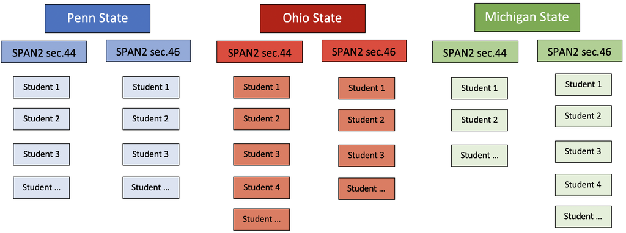

Multilevel models have a series of benefits that make them superior to other methods:

**1. Heterogeneity of slopes:** unlike linear regression or ANOVA, multilevel models are especially designed to model variability in regression slopes, homogeneity of variance is not assumed.

**2. Assumption of independence:** multilevel models deal with nested data and, as such, do not assume that data points are necessarily independent of each other. In fact, they are designed to model this dependency.

**3. Missing data:** they can handle missing data really well, unlike regression or ANOVA.

**4. Variance:** a single analysis including random effects of participant and item can replace the usual separate ANOVAs by participant and by item.

### Fixed vs. Random

**1. Coefficients: Intercepts and Slopes**

- *Random intercepts:* the relationship between x-y (predictor-outcome) is the *same* (tilt doesn’t change), just located at *different* geometric space.  
  In a nutshell:  
  Random intercepts model the variance between subjects and between items **in the mean of the dependent variable**. For example, some participants may generally read sentences faster than others, and thus have lower intercepts; or some items may be read more slowly than others, and thus have higher intercepts.
- *Random slopes:* the relationship between x-y is *different* (tilt changes), but located at the *same* geometric space.  
  In a nutshell:  
  Random slopes model the variance between subjects and between items **for all main effects and interactions**. For example, some participants may read active sentences much faster than the passive sentences, having a more pronounced tilt to their slopes; while another subset of participants may show this same trend but with a smaller difference, have a less pronounced tilt.
- *Random intercepts and slopes:* the relationship between x-y varies by shape and location. This is the most realistic model of the data.

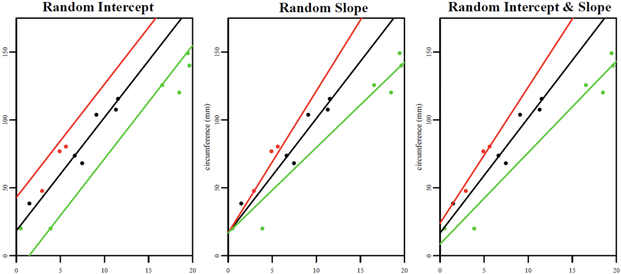

**2. Variables**

The distinction between fixed and random variables is be crucial when considering which predictors can de included in our random effects structure.

- Fixed variables are those which *do not change* over time, for example a person’s gender.
- Random variables are those which *change* over time, for example a person’s weight or age.

**3. Effects**

Models that include **both** fixed and random effects are called *Mixed Effects Models.*

**1. Fixed effects** most commonly represent the experimental manipulation designed (*fixed*) by the researcher. We are *only* interested in the levels of our manipulation (i.e., conditions).

**1. Random effects** are those of which the experiment contains only a *random* sample of possible conditions. For example, because we choose a random sample of participants and items, the analysis cannot compute the effect of *all* types people and *all* types of items. Instead, it will estimate the variability attributable to our random sample of each.  
*Note: unfortunately, a discussion on nested vs. crossed random effects is out of scope, but read on it [here](https://stats.stackexchange.com/questions/228800/crossed-vs-nested-random-effects-how-do-they-differ-and-how-are-they-specified)

**CRUCIALLY: WE GENERALIZE THE RESULTS OF OUR FIXED EFFECTS ONTO OUR RANDOM EFFECTS AND, FROM THAT, TO THE GENERAL POPULATION.**

**EXAMPLE:** We generalize the results of a reading experiment with **actives/passives (CONDITIONS = FIXED)** onto monolingual and bilingual speakers **(PARTICIPANTS = RANDOM)**. Our study is made stronger by being able to generalize to a larger population by means of our random effects, than just being able to make an assertion about a particular group of participants if we only had fixed effects.

### Covariance Structures

When creating a mixed effects model, we have to decide upon its *covariance structure*. In other words, will we have random intercepts and/or slopes *AND* which variables can be included in each.

First, we will create a model *with random intercepts only*. * The notation *(1 | x)* indicates that this is a random effect * *1|* denotes it’s a random intercept * *x* refers to the grouping variable

**CAREFUL:** when we specify a covariance structure that is too simple, then we are more likely to observe a Type I error (aka false positive). More information on random effects terms in R here

```r
model_RI <- lmer(total ~ center_congruency*center_voice # fixed effects
                                  + (1 | participant) # random intercept by participant
                                  + (1 |item) # random intercept by item
                                  , data = data
                                  , REML = TRUE
                                  , control = lmerControl(optimizer = "bobyqa"))
summary(model_RI)
```

```
## Linear mixed model fit by REML. t-tests use Satterthwaite's method [
## lmerModLmerTest]
## Formula: total ~ center_congruency * center_voice + (1 | participant) +
##     (1 | item)
##    Data: data
## Control: lmerControl(optimizer = "bobyqa")
##
## REML criterion at convergence: 23825.3
##
## Scaled residuals:
##     Min      1Q  Median      3Q     Max
## -3.3320 -0.5914 -0.1440  0.4435  5.1659
##
## Random effects:
##  Groups      Name        Variance Std.Dev.
##  item        (Intercept)  15446   124.3
##  participant (Intercept)  53876   232.1
##  Residual                135174   367.7
## Number of obs: 1616, groups:  item, 80; participant, 30
##
## Fixed effects:
##                                Estimate Std. Error      df t value Pr(>|t|)
## (Intercept)                      905.57      45.92   32.24  19.719  < 2e-16 ***
## center_congruency                 91.36      18.61 1536.13   4.909 1.01e-06 ***
## center_voice                     157.60      18.60 1537.84   8.473  < 2e-16 ***
## center_congruency:center_voice    88.14      37.20 1536.44   2.369   0.0179 *
## ---
## Signif. codes:  0 '***' 0.001 '**' 0.01 '*' 0.05 '.' 0.1 ' ' 1
##
## Correlation of Fixed Effects:
##             (Intr) cntr_c cntr_v
## cntr_cngrnc -0.003
## center_voic  0.000  0.000
## cntr_cngr:_  0.001  0.005  0.006
```

Let’s dissect the output:

#### **2. Scaled residuals**

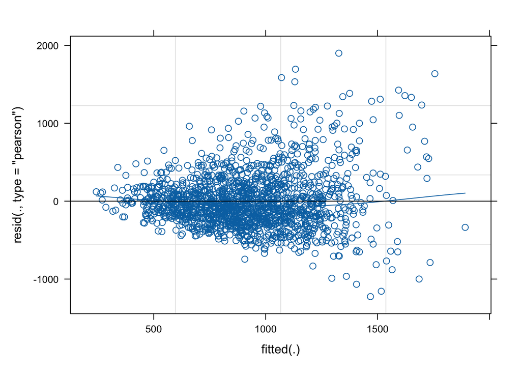

```r
plot(model_RI,type=c("p","smooth"))
```

#### **3. Random effects**

This part of the model output is often neglected, even though it can give us important information about our model.

The standard deviation of random effects can tell us how much the intercepts varied over our participant and item variables. In this particular case, we see the standard deviations are not huge which for data set of this size. This entails there aren’t huge differences in RTs for our participant sample. This also means that we controlled for our items properly, as there aren’t huge differences in the RTs for different sentences.

#### **4. Fixed Effects**

Now, we will create a model that also contains *random slopes*:

```r
model_RS <- lmer(total ~ center_congruency*center_voice # fixed effects
                                  + (1 + center_congruency+center_voice | participant) # random intercept & slope by participant
                                  + (1 + center_congruency+center_voice |item) # random intercept & slope by item
                                  , data = data
                                  , REML = TRUE
                                  , control = lmerControl(optimizer = "bobyqa"))
```

```
## boundary (singular) fit: see help('isSingular')
```

```r
summary(model_RS)
```

```
## Linear mixed model fit by REML. t-tests use Satterthwaite's method [
## lmerModLmerTest]
## Formula: total ~ center_congruency * center_voice + (1 + center_congruency +
##     center_voice | participant) + (1 + center_congruency + center_voice |
##     item)
##    Data: data
## Control: lmerControl(optimizer = "bobyqa")
##
## REML criterion at convergence: 23814.4
##
## Scaled residuals:
##     Min      1Q  Median      3Q     Max
## -3.4017 -0.6000 -0.1415  0.4324  4.9841
##
## Random effects:
##  Groups      Name              Variance Std.Dev. Corr
##  item        (Intercept)        15764.2 125.56
##              center_congruency    411.3  20.28   1.00
##              center_voice         154.9  12.45   1.00 1.00
##  participant (Intercept)        53836.4 232.03
##              center_congruency   2047.0  45.24   0.93
##              center_voice        3995.1  63.21   0.71 0.92
##  Residual                      133544.2 365.44
## Number of obs: 1616, groups:  item, 80; participant, 30
##
## Fixed effects:
##                                Estimate Std. Error      df t value Pr(>|t|)
## (Intercept)                      905.46      45.91   32.83  19.723  < 2e-16 ***
## center_congruency                 85.48      20.42   66.74   4.186 8.50e-05 ***
## center_voice                     152.07      21.97   26.95   6.922 1.96e-07 ***
## center_congruency:center_voice    82.48      37.05 1526.64   2.226   0.0262 *
## ---
## Signif. codes:  0 '***' 0.001 '**' 0.01 '*' 0.05 '.' 0.1 ' ' 1
##
## Correlation of Fixed Effects:
##             (Intr) cntr_c cntr_v
## cntr_cngrnc 0.385
## center_voic 0.371  0.208
## cntr_cngr:_ 0.001  0.008  0.010
## optimizer (bobyqa) convergence code: 0 (OK)
## boundary (singular) fit: see help('isSingular')
```

The results are largely similar to the ones of the previous model, however, we do see that the AIC value has gone up slightly, indicating that this second model’s fit is somewhat worse. If we compare both models, we see that model with random slopes does not improve over the model random intercepts. Thus, random intercepts are enough to account for the variance in this data set.

In addition, the warning message *boundary (singular) fit: see help(‘isSingular’)* indicates that we are over-fitting our random effects structure. In other words, specifying a highly complicated model is not warranted in this case.

```r
anova(model_RI, model_RS)
```

```
## refitting model(s) with ML (instead of REML)
```

```
## Data: data
## Models:
## model_RI: total ~ center_congruency * center_voice + (1 | participant) + (1 | item)
## model_RS: total ~ center_congruency * center_voice + (1 + center_congruency + center_voice | participant) + (1 + center_congruency + center_voice | item)
##          npar   AIC   BIC logLik deviance  Chisq Df Pr(>Chisq)
## model_RI    7 23873 23911 -11930    23859
## model_RS   17 23882 23974 -11924    23848 10.735 10     0.3785
```

Now, the models that we have built so far are somewhat simple, we don’t have a large number of variables. In other words, these models are *parsimonious*, they include a conservative number of predictors. However, we could also create *maximal* models that include all possible predictors we are interested in, as well as their interactions. Let’s look into these possibilities:

**1. Barr et al., (2013) Random effects structure for confirmatory hypothesis testing: Keep it maximal**

Key points:

- Using maximal random-effects structures in our models can help reduce the risk of Type I error.
- Maximal random-effects structures make findings more generalizable.

**2. Bates et al., (2015) Parsimonious Mixed Models**

Key points:

- Maximal models create worrying convergence issues.
- Maximal models can critically overfit the data.
- Iterative reduction (i.e., stepwise selection) to create parsimonious models is preferable.

Since the advent of the study by Bates et al., few researchers use the maximal approach given its many disadvantages. In our case, if we wanted to create a larger model, we’d still need to compare it with simpler models to make sure that each predictor that we include actually improves the model’s fit. This is were **stepwise regression** can help us.

Stepwise regression (or stepwise selection) consists of iteratively adding and/or removing predictors in order to find the subset of variables resulting in the best performing model.

There are three strategies in stepwise regression:

- **Forward selection**, which starts with no predictors in the model, iteratively adds the most contributive predictors, and stops when the improvement is no longer statistically significant.
- **Backward selection**, (or backward elimination), which starts with all predictors in the model (maximal/dull model), iteratively removes the least contributive predictors, and stops when you have a model where all predictors are statistically significant.
- **Stepwise selection**, (or sequential replacement), which is a combination of forward and backward selections. You start with no predictors, then sequentially add the most contributive predictors (like forward selection). After adding each new variable, remove any variables that no longer provide an improvement in the model fit (like backward selection). This tests all possible combinations aming variables.

There are several ways in which stepwise selection can be performed, here we will talk about two:

**1. Manual selection:** we have actually already done this above; this method consists of manually adding or subtracting a variable and then comparing models to check if the AIC values have improved (we can also use the anova function)

**2. Using the function buildmer()**

This function uses lmer from the `lme4` package but allows for *a systematic and replicable* way of simplifying random effects structures and testing fixed effects. The function starts by attempting to fit the most maximal model possible. If the model fails to converge, the function then simplifies the random effects structure via backwards stepwise elimination; in other words, it attempts to find the maximal random effects structure that still allows the model to converge. Once the maximally converging model has been identified, the function calculates p-values for all fixed effects. **The resulting model is the maximally converging model that the data are able to support.**

[output not shown]

```r
summary(model_build)
```

```
## Linear mixed model fit by REML
## (p-values based on Wald z-scores) ['lmerMod']
## Formula:
## total ~ 1 + center_voice + center_congruency + center_voice:center_congruency +
##     (1 + center_voice | participant) + (1 | item)
##    Data: data
## Control: lmerControl(optimizer = "bobyqa")
##
## REML criterion at convergence: 23819.9
##
## Scaled residuals:
##     Min      1Q  Median      3Q     Max
## -3.5173 -0.5915 -0.1457  0.4286  5.0732
##
## Random effects:
##  Groups      Name         Variance Std.Dev. Corr
##  item        (Intercept)   15455   124.32
##  participant (Intercept)   53914   232.19
##              center_voice   3574    59.79   0.75
##  Residual                 134323   366.50
## Number of obs: 1616, groups:  item, 80; participant, 30
##
## Fixed effects:
##                                Estimate Std. Error t value Pr(>|t|)
## (Intercept)                      905.31      45.93  19.711  < 2e-16 ***
## center_voice                     154.51      21.62   7.148 8.82e-13 ***
## center_congruency                 90.05      18.56   4.852 1.22e-06 ***
## center_voice:center_congruency    87.64      37.11   2.362   0.0182 *
## ---
## Signif. codes:  0 '***' 0.001 '**' 0.01 '*' 0.05 '.' 0.1 ' ' 1
##
## Correlation of Fixed Effects:
##             (Intr) cntr_v cntr_c
## center_voic  0.357
## cntr_cngrnc -0.003 -0.001
## cntr_vc:cn_  0.000  0.005  0.006
```

Let’s dissect this output;

#### Formula

The standard deviations for the Random effects are fairly similar to those of our smaller model; we see they are still higher for participant than for item, indicating there was more variation in the former.

### Resources

- Magezi (2015) Linear mixed-effects models for within-participant psychology experiments
- Austin et al., (2001) An Introduction to Multilevel Regression Models
- Balling (2008) A brief introduction to regression designs and mixed-effects modeling by a recent convert
- Cunnings (2012) An overview of mixed-effects statistical models for second language researchers
- Barr et al., (2013) Random effects structure for confirmatory hypothesis testing: Keep it maximal
- Bates et al., (2015) Parsimonious Mixed Models
- Lever et al., (2015) Model selection and overfitting
- http://bbolker.github.io/mixedmodels-misc/glmmFAQ.html
- http://www.rensenieuwenhuis.nl/r-sessions-16-multilevel-model-specification-lme4/
- https://www.youtube.com/watch?v=1rTb72pCPT8&ab_channel=StatisticsofDOOM
- https://rstudio-pubs-static.s3.amazonaws.com/78961_fe5b5c6a77f446eca899afbb32bd1dc7.html
- https://github.com/cvoeten/buildmer
- http://web.pdx.edu/~newsomj/mlrclass/ho_randfixd.pdf
- https://web.ma.utexas.edu/users/mks/statmistakes/fixedvsrandom.html